# AP Calculus BC Scores Grapher

**By Greg Brown, 7/25/2019**

## Overview

From the current working directory, this program reads a user-submitted .csv file which contains AP Calculus BC score data. The program displays various plots of AP Calculus BC score data. This program helps me visualize my own students' performance. For this notebook, I used my own personal AP Calculus BC data from my own career at Francis Howell North High School. I discuss my analysis of the data after each plot, summarize big points for all the data, and formulate a goal for next year at the end.

#### Disclaimer

AP Calculus students have the option of receiving transferable college credit through UMSL for this class. The following data does not reflect student success through UMSL, it only monitors student success on the AP Calculus exam.

#### Official College Board Recommendation Based on AP Exam Score

A score of 3 is considered a qualifying score, 4 is considered very well qualified, and 5 is considered extremely well qualified.

```python
#import packages
import pandas as pd
import matplotlib.pyplot as plt
import numpy as np
```

```python
#load the file
file = input("type the filename of the AP Calculus BC scores: ")
bcScores = pd.read_csv(file)

#display data
print()
print("here is he raw data")
print(bcScores)
```

```
type the filename of the AP Calculus BC scores: greg_brown_ap_calculus_bc_scores.csv

here is he raw data
   Year  Number of 1s  Number of 2s  Number of 3s  Number of 4s  Number of 5s  \
0  2017             2             6             4             0             4
1  2018             1             6             2             4             7
2  2019             0             1             5             6             3

   Total Tests Taken  Percent 3 or Higher  Average Score
0                 16            50.000000       2.875000
1                 20            65.000000       3.500000
2                 15            93.333333       3.733333
```

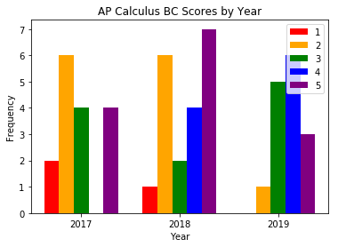

```python
#in this section we will look at the calculus ab scores by year

#create subplot
figure1 = plt.subplot()

#create individual bar plot for every AP Calculus AB score
figure1.bar(np.array(bcScores["Year"] - .30), bcScores["Number of 1s"], .15, label="1", color="red")
figure1.bar(np.array(bcScores["Year"] - .15), bcScores["Number of 2s"], .15, label="2", color="orange")
figure1.bar(np.array(bcScores["Year"] + .00), bcScores["Number of 3s"], .15, label="3", color="green")
figure1.bar(np.array(bcScores["Year"] + .15), bcScores["Number of 4s"], .15, label="4", color="blue")
figure1.bar(np.array(bcScores["Year"] + .30), bcScores["Number of 5s"], .15, label="5", color="purple")

#create labels
figure1.set_title("AP Calculus BC Scores by Year")
figure1.set_ylabel("Frequency")
figure1.set_xlabel("Year")
figure1.set_xticks(bcScores["Year"])
figure1.legend()


#show subplot
plt.show()
```

### AP Calculus BC Scores by Year

The graph shows a few trends. The number of 1s steadily decreased from two in 2017 to zero in 2019. The number of 4s increased from 0 in 2017 to 6 in 2019. Even though 2019 has the smallest number of 1s and 2s, it also has the smallest number of 5s. There were seven 5s in 2018.

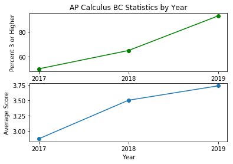

```python
#now we will plot the average score per year and the percent 3 or higher per year, side by side

#create plot
plt.figure()


#create the percent 3 or higher subplot
plt.subplot(211)
plt.subplot(211).set_title("AP Calculus BC Statistics by Year")
plt.plot(bcScores["Year"], abScores["Percent 3 or Higher"], color="green", marker='o')
plt.subplot(211).set_ylabel("Percent 3 or Higher")
plt.subplot(211).set_xlabel("Year")
plt.subplot(211).set_xticks(bcScores["Year"])


#create the average score subplot
plt.subplot(212)
plt.plot(bcScores["Year"], bcScores["Average Score"], marker='o')
plt.subplot(212).set_ylabel("Average Score")
plt.subplot(212).set_xlabel("Year")
plt.subplot(212).set_xticks(bcScores["Year"])


#show plot
plt.show()
```

### AP Calculus BC Statistics by Year

##### Percent 3 or Higher

Starting at 50% in 2017, the percent of 3 or higher scores increased to 93% in 2019. The percent of 3 or higher AP Calculus BC scores is increasing at a faster rate.

# Overall Conclusion for AP Calculus BC scores

AP Calculus BC performance has been steadily increasing to their highest numbers yet in 2019. 93% of students earning a 3 or higher is exceptional.

# Goal for next year

My goal for AP Calculus BC in 2020 is to have at least seven 5s, 100% 3 or higher, and an average score of at least 4.